# Ford GoBike Exploration

## by Jonathan Obise

## Investigation Overview

> This data set includes information about individual rides made in a bike-sharing system covering the greater San Francisco Bay area.

> To prepare the data, I loaded it in from a csv file and converted the start and end time columns to datetime, extracted the dayofweek and hours information from the start_time variable and converted the start_time_dayofweek to ordinal variables.

## Dataset Overview

> Bay Wheels (Formerly Ford GoBike) is a regional public bicycle sharing system in California's San Francisco Bay Area. It is operated by Motivate in a partnership with the Metropolitan Transportation Commission and the Bay Area Air Quality Management District. Bay Wheels is 'the first regional and large-scale bicycle sharing system deployed in California and on the West Coast of the United States. It was established as Bay Area Bike Share in August 2013. As of January 2018, the Bay Wheels system had over 2,600 bicycles in 262 stations across San Francisco, East Bay and San Jose.

> In June 2017 the system was officially re-launched as Ford GoBike in a partnership with Ford Motor Company. After Motivate's acquisition by Lyft, the system was renamed to Bay Wheels in June 2019. The system is expected to expand to 7,000 bicycles around 540 stations in San Francisco, Oakland, Berkeley, Emeryville, and San Jose.

## (Visualization 1)

> Visualize the distribution of variable in the data by creating various univariates plots

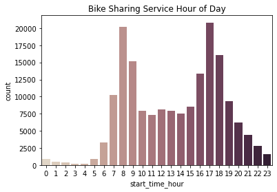

> **We observe from the data that the peak hours were registered mostly at 8am and 5pm. This corresponds to the rush hours when people commute to and from work.**

## (Visualization 2)

> Create visualizations to show potential relationships between the variables in the dataset

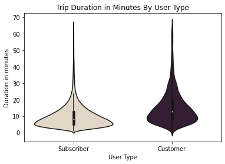

> It does appear like subscribers have shorter trips and a more specific usage or targeted goal riding the bikes compared to customers who vary more and seem to generally rent the bikes for longer periods of time.

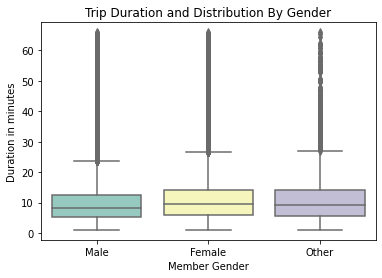

> Not so much in terms of the disparities but we see members of the female gender tend to take longer rides as compared to the male gender. This is also corroborated by the higher median and Interquartile range (IQR) for the female gender as seen on the plot.

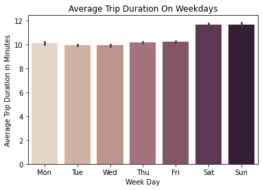

> As expected, Saturdays and Sundays were days that registered the longest trips. This is not surprising since it is weekend and most people don't work on these days.

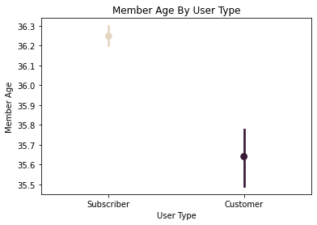

> Subscribers were older than customers. This is understandable since we can deduce that most riders belonged to the working class.

## (Visualization 3)

> Use multivariate visualizations to get an understanding of the dataset

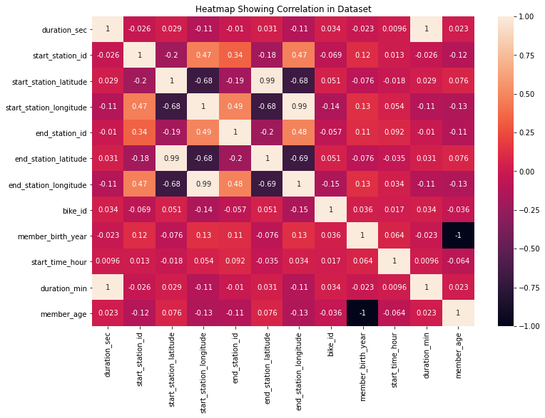

> The heatmap helps to narrow down on the variables that are correlated in the dataset.

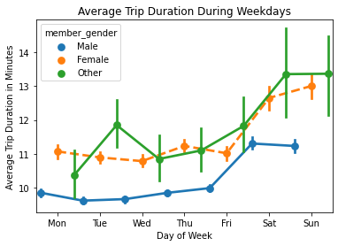

> Female bikers biked longer than their male counterparts. With weekends seeing the most rides.

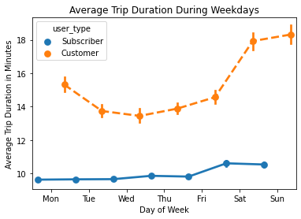

Customers had an overall longer duration of trips during weekdays. However, both subscribers and customers experienced increase in trip duration during weekends.